# Examples with the “borrow” Package

Nan Chen

Dec. 15, 2019

## Study Data

In this study, we use the vemu data to illustrate the usages of the borrow package. The dat set is:

Summary of Response Data

| baskets | evaluable | responders |
| --- | --- | --- |
| NSCLC | 19 | 8 |
| CRC (vemu) | 10 | 0 |
| CRC (vemu+cetu) | 26 | 1 |
| Bile Duct | 8 | 1 |
| ECD or LCH | 14 | 6 |
| ATC | 7 | 2 |

## borrow Package: Single Subgroup Estimation Example

With the single subgroup estimationo, we can conduct the analysis of the subgroup we are interested, For instance, if we are interested in the subgroup 2, we can calculate the MAP and the PEP of the subgroup with other subgroups. We can also estimate posterior probability $p(\theta_i>p_0)$, the effective sample size (ESS).

```r
library(borrow)

# drug_index is the index number of the basket we are interested
exact_single <- mem_single(
    responses = vemu_wide1$responders,
    size = vemu_wide1$evaluable,
    name = vemu_wide1$baskets,
    drug_index = 2,
    p0 = 0.25
  )

exact_single$PEP
```

```
##           NSCLC      CRC (vemu) CRC (vemu+cetu)       Bile Duct
##       0.1265905       1.0000000       0.6543800       0.6897220
##      ECD or LCH             ATC
##       0.1436163       0.4393099
```

```r
summary(exact_single)
```

```
##    Post.Prob       HPD LB       HPD HB          ESS         Mean
## 1.117702e-01 4.894015e-07 3.182003e-01 1.253000e+01 1.066093e-01
##       Median
## 7.345469e-02
```

## borrow Package: Multiple Subgroups Estimation Example

We can conduct the analysis of multiple subgroups in the trial. For instance,if we are interested in the subgroup 2 and 3, we can perform this calculation:

```r
testMult <- borrow_multiple(
  responses = vemu_wide1$responders,
  size = vemu_wide1$evaluable,
  name = vemu_wide1$baskets,
  drug_index = 2:3,
  p0 = 0.25
)
summary(testMult)
```

```
## $MAP
##                 NSCLC CRC (vemu) CRC (vemu+cetu) Bile Duct ECD or LCH ATC
## CRC (vemu)          0          1               1         1          0   0
## CRC (vemu+cetu)     0          1               1         1          0   0
##
## $PEP
##                      NSCLC CRC (vemu) CRC (vemu+cetu) Bile Duct ECD or LCH
## CRC (vemu)      0.12659049  1.0000000         0.65438 0.6897220 0.14361632
## CRC (vemu+cetu) 0.04096607  0.6999464         1.00000 0.7086455 0.05870901
##                       ATC
## CRC (vemu)      0.4393099
## CRC (vemu+cetu) 0.3986760
##
## $post.prob
##      CRC (vemu) CRC (vemu+cetu)
##      0.11177019      0.01552058
##
## $HPD
##                     [,1]        [,2]
## Lower Bound 8.969807e-07 0.001064561
## Upper Bound 3.124533e-01 0.193661567
##
## $mean_est
##      CRC (vemu) CRC (vemu+cetu)
##      0.10588465      0.07848089
##
## $median_est
##      CRC (vemu) CRC (vemu+cetu)
##      0.07365560      0.06551837
##
## $ESS
##      CRC (vemu) CRC (vemu+cetu)
##           13.02           29.76
```

We can conduct the analysis of all subgroups with the multiple subgroup calculation for the trial. For instance,

```r
testMult1 <- borrow_multiple(
  responses = vemu_wide1$responders,
  size = vemu_wide1$evaluable,
  name = vemu_wide1$baskets,
  drug_index = 1:6,
  p0 = 0.25
)

res <- summary(testMult1)$PEP
summary(testMult1)$post.prob
```

```
##           NSCLC      CRC (vemu) CRC (vemu+cetu)       Bile Duct
##      0.91260022      0.11177019      0.01552058      0.44411657
##      ECD or LCH             ATC
##      0.88743790      0.65093627
```

```r
dat <- data.frame(res)
library(knitr)
kable(dat, caption="Summary of Posterior Probabilities", align='lcc', row.names=F, format='html')
```

Summary of Posterior Probabilities

| NSCLC | CRC..vemu. | CRC..vemu.cetu. | Bile.Duct | ECD.or.LCH | ATC |
| --- | --- | --- | --- | --- | --- |
| 1.0000000 | 0.0911851 | 0.0275875 | 0.5079017 | 0.7577126 | 0.7312597 |
| 0.1265905 | 1.0000000 | 0.6543800 | 0.6897220 | 0.1436163 | 0.4393099 |
| 0.0409661 | 0.6999464 | 1.0000000 | 0.7086455 | 0.0587090 | 0.3986760 |
| 0.4011098 | 0.3923561 | 0.3768778 | 1.0000000 | 0.4122537 | 0.6020709 |
| 0.7466537 | 0.1019392 | 0.0389590 | 0.5143936 | 1.0000000 | 0.7293790 |
| 0.5669500 | 0.2453391 | 0.2081522 | 0.5910675 | 0.5738676 | 1.0000000 |

We can also obtain the informationo of ESS of all subgroups:

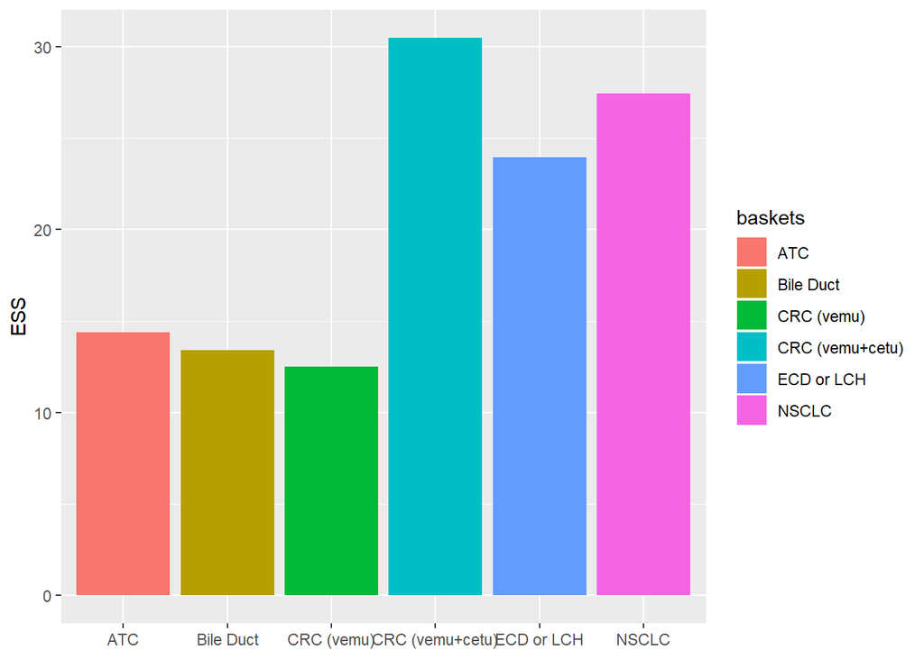

```r
ess <- summary(testMult1)$ESS
df <- data.frame(baskets = vemu_wide1$baskets, ESS = ess)

p<-ggplot(df, aes(x=baskets, y=ESS, fill = baskets)) + labs(y = "ESS")+
  geom_bar(stat="identity")+theme(axis.title.x = element_blank())

p
```

## borrow Package: Trial Simulation Example

We can use this package to conduct the simulation based trial design. The simulator supports parallel computation and users can use multiple CPU cores for simulation conduction. In the trial simulation, some basket responses are known and those responses are fixed in the simulation. In the input, we set the is.resp.rate of these subgroups as FALSE and the resp variable as the response outcome. Responses of some subgroups are unknown and we set the is.resp.rate of these subgroups as TRUE and the resp variable as the true response rates in the simulation. For instance, we would like to perform a trial simulation with 100 runs, subgroups 1, 2, and 4 are with unknown outcomes:

```r
library(doParallel)
library(foreach)

numCores <- detectCores()
registerDoParallel(numCores)

resp <- vemu_wide1$responders
resp[1:2] <- rep(0.1, 2)
resp[4] <- 0.3
testSim <- borrow_simulate(
  resp =  resp,
  is.resp.rate = c(TRUE, TRUE, FALSE, TRUE, FALSE, FALSE),
  size = vemu_wide1$evaluable,
  name = vemu_wide1$baskets,
  drug_index = c(2, 4),
  p0 = 0.2,
  num_sim = 100
)
```

Users can access the data of each individual trial simulation. For example, one can access the PEP of the 20th trial simlation:

```r
source("update.r")
testSim <- readRDS("testSim.rds")

print(testSim$data[[20]]$PEP)
```

```
##                NSCLC CRC (vemu) CRC (vemu+cetu)  Bile Duct ECD or LCH
## CRC (vemu) 0.7775754  1.0000000      0.77432907 0.05148534 0.04644852
## Bile Duct  0.1329623  0.1207016      0.08016462 1.00000000 0.68711447
##                  ATC
## CRC (vemu) 0.3337679
## Bile Duct  0.6801829
```

One can also summarize the results of all simulations.

```r
res <- summary(testSim)
res$Avg.MAP
```

```
##            NSCLC CRC (vemu) CRC (vemu+cetu) Bile Duct ECD or LCH  ATC
## CRC (vemu)  0.88       1.00            0.76      0.68       0.19 0.50
## Bile Duct   0.63       0.66            0.43      1.00       0.53 0.77
```

```r
s <- res$result
dat <- data.frame(s)
library(knitr)
kable(dat, caption="Summary of Simulation Results", align='lcc', row.names=F, format='html')
```

Summary of Simulation Results

| Post.prob.Mean | Post.prob.25. | Post.prob.75. | ESS.Mean | ESS.25. | ESS75. |
| --- | --- | --- | --- | --- | --- |
| 0.2438914 | 0.0748319 | 0.3499685 | 24.4872 | 17.4750 | 28.9900 |
| 0.4579017 | 0.2052847 | 0.7192901 | 19.2447 | 13.9475 | 22.6925 |

One can plot the posteror probability distribution use the density plot or violin plot

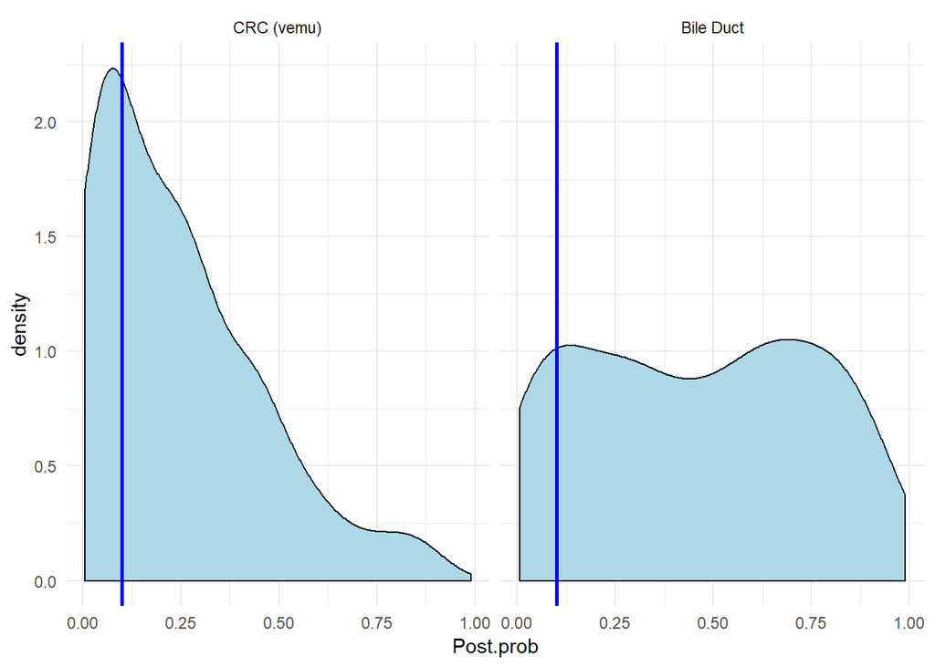

```r
plot_sim(testSim, threshold = c(0.1, 0.1))
```

```
## $`Baskets..Posterior Prob`
```

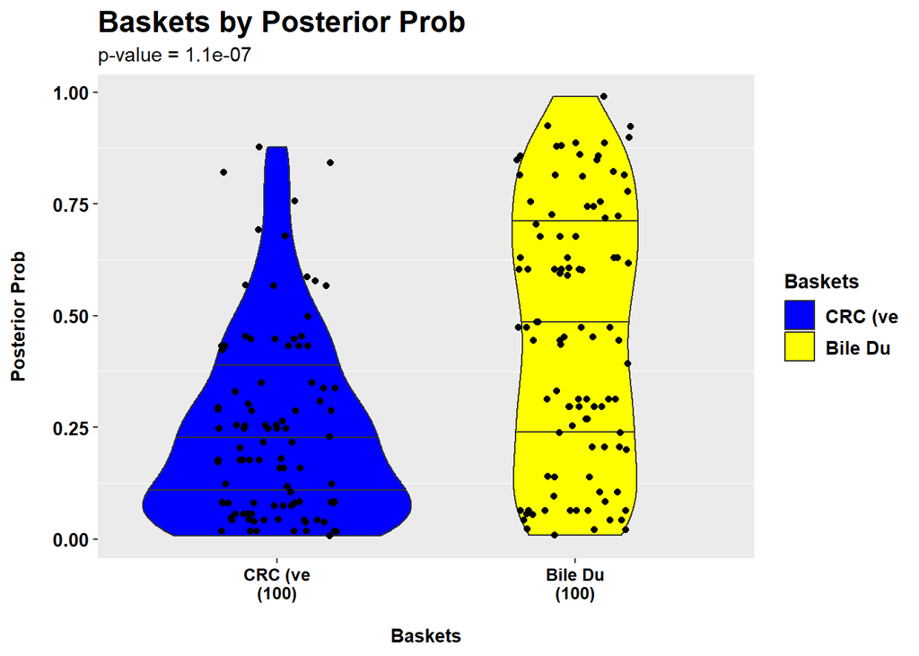

```r
plot_sim_violin(testSim)
```

## borrow Package: Threshold Value Calibration Example

One can use the simulation results to calibrate the threshold values based on the Type I error or the power values.

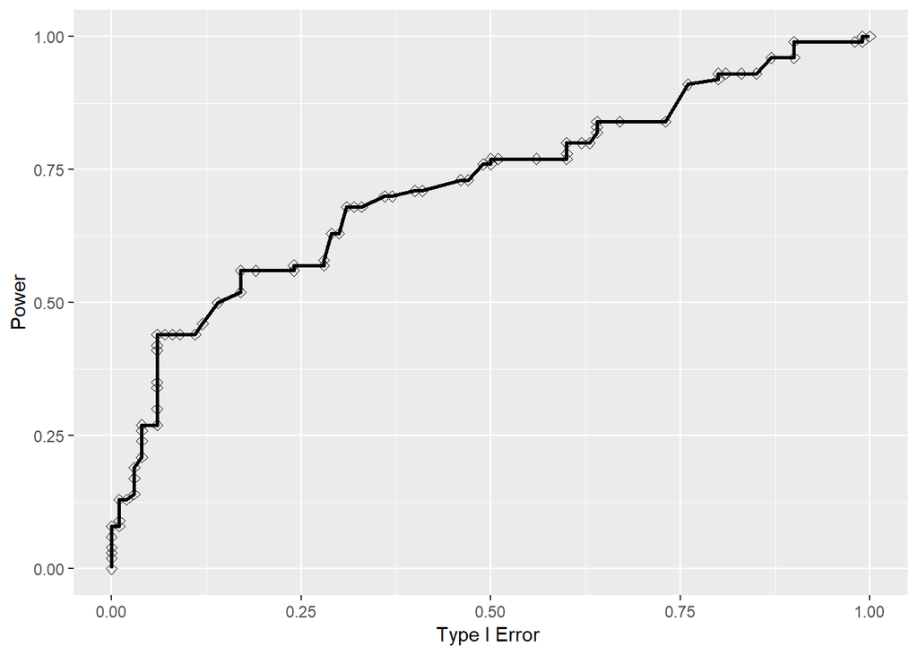

```r
oc <- ocCurve(nullData = res$allPostProb[,1], alterData= res$allPostProb[,2])
plot.occurve(oc)
```

```r
t1 <- cali.onPower(oc, powerV = c(0.7, 0.8, 0.9))
```

[figure not shown]

```r
t2 <- cali.onTypeIError(oc, typeIError = c(0.1, 0.2, 0.3))
```

[figure not shown]

```r
dat <- data.frame(t1)
library(knitr)
kable(dat, caption="Summary of Calibration based on Power", align='lcc', row.names=F, format='html')
```

Summary of Calibration based on Power

| Power | Cutoff | Pred.TError |
| --- | --- | --- |
| 0.7 | 0.264 | 0.371 |
| 0.8 | 0.121 | 0.613 |
| 0.9 | 0.063 | 0.751 |

```r
dat <- data.frame(t2)

kable(dat, caption="Summary of Calibration based on Type I Error", align='lcc', row.names=F, format='html')
```

Summary of Calibration based on Type I Error

| TError | Cutoff | Pred.Power |
| --- | --- | --- |
| 0.1 | 0.529 | 0.446 |
| 0.2 | 0.426 | 0.565 |
| 0.3 | 0.305 | 0.638 |